# Homework 1

Jason Ofosu-Mensah

##### Citation

This homework assignment is largely borrowed from Coursework created Prof. Alexandra Chouldechova at Carnegie Mellon University. I have modified slightly and am using in accordance with the Creative Commons License:

Creative Commons Attribution-NonCommercial-ShareAlike 4.0 International License(http://creativecommons.org/licenses/by-nc-sa/4.0/)

##### This homework is due by **11:55PM on Friday, Sep 22**.

##### To complete this assignment, follow these steps:

1. Download the `homework1.Rmd` file from Moodle
2. Open `homework1.Rmd` in RStudio.
3. Replace the “Your Name Here” text in the `author:` field with your own name.
4. Supply your solutions to the homework by editing `homework1.Rmd`.
5. When you have completed the homework and have **checked** that your code both runs in the Console and knits correctly when you click `Knit HTML`, rename the R Markdown file to `homework1_YourNameHere.Rmd`, and submit both the `.Rmd` file and the `.html` output file on Blackboard. (YourNameHere should be changed to your own name.)

##### Homework tips:

1. Recall the following useful RStudio hotkeys.

| Keystroke | Description |
| --- | --- |
| `<tab>` | Autocompletes commands and filenames, and lists arguments for functions. |
| `<up>` | Cycles through previous commands in the console prompt |
| `<ctrl-up>` | Lists history of previous commands matching an unfinished one |
| `<ctrl-enter>` | Runs current line from source window to Console. Good for trying things out ideas from a source file. |
| `<ESC>` | Aborts an unfinished command and get out of the + prompt |

**Note**: Shown above are the Windows/Linux keys. For Mac OS X, the `<ctrl>` key should be substituted with the `<command>` (⌘) key.

2. Instead of sending code line-by-line with `<ctrl-enter>`, you can send entire code chunks, and even run all of the code chunks in your .Rmd file. Look under the menu of the Source panel.
3. Run your code in the Console and Knit HTML frequently to check for errors.
4. You may find it easier to solve a problem by interacting only with the Console at first, or by creating a separate `.R` source file that contains only R code and no Markdown.

### Housekeeping - packages to be used.

We will give preference to the “tidyverse” of packages related to “Tidy Data.”

```r
library(knitr)
library(tidyverse) # loads ggplot2, dplyr,tidyr,readr,purr,tibble
library(magrittr)
library(ggplot2)

library(FNN)

library(ISLR)

library(DT)

library(broom)  # because I find it useful

cbPalette <- c("#999999", "#E69F00", "#56B4E9", "#009E73", "#F0E442", "#0072B2", "#D55E00", "#CC79A7")

options(scipen = 4)  # make output prefer not to use scientific notation
```

### Introduction: Bikeshare data

For this problem we’ll be working with two years of bikeshare data from the Capital Bikeshare system in Washington DC. The dataset contains daily bikeshare counts, along with daily measurements on environmental and seasonal information that may affect the bikesharing.

### Data pre-processing

Let’s start by loading the data.

```r
bikes <- read.csv("http://www.andrew.cmu.edu/user/achoulde/95791/data/bikes.csv", header = TRUE)

# Transform temp and atemp to degrees C instead of [0,1] scale
# Transform humidity to %
# Transform wind speed (multiply by 67, the normalizing value)

bikes <- mutate(bikes,
                   temp = 47 * temp - 8,
                   atemp = 66 * atemp - 16,
                   hum = 100 * hum,
                   windspeed = 67 * windspeed)

# The recode() command from the dplyr library allows us to easily
# rename values in our variables.  Below we use this command to change season
# from numeric codings to season names.

bikes <- mutate(bikes,
                   season = recode(season, `1`="Winter",`2`="Spring",
                                      `3`="Summer", `4`="Fall"))
```

Let’s look at some boxplots of how bikeshare ride count varies with season.

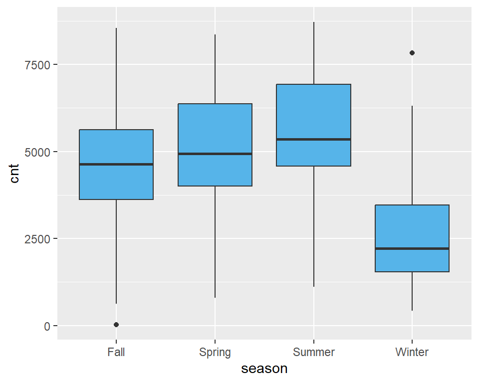

```r
qplot(data = bikes, x = season, y = cnt, fill = I(cbPalette[3]), geom = "boxplot")
```

There’s something funny going on here. Instead of showing up in seasonal order, the seasons in the plot are showing up in **alphabetical order**. The following command reorders the seasons appropriately.

```r
bikes <- mutate(bikes, season = factor(season, levels = c("Winter", "Spring", "Summer", "Fall")))
```

Now let’s try that plot again.

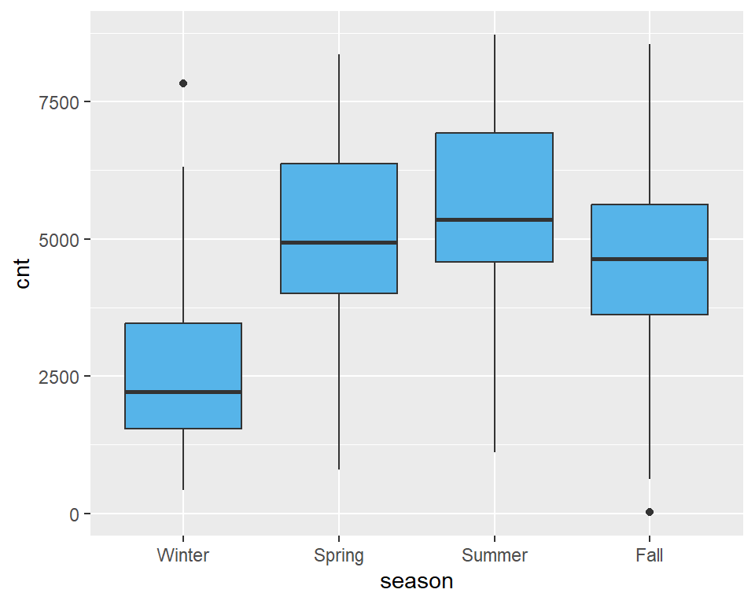

```r
qplot(data = bikes, x = season, y = cnt, fill = I(cbPalette[3]), geom = "boxplot")
```

Here’s information on what the variables mean.

- instant: record index
  - dteday : date
  - season : season (1:Winter, 2:Spring, 3:Summer, 4:Fall)
  - yr : year (0: 2011, 1:2012)
  - mnth : month ( 1 to 12)
  - hr : hour (0 to 23)
  - holiday : weather day is holiday or not (extracted from http://dchr.dc.gov/page/holiday-schedule)
  - weekday : day of the week
  - workingday : if day is neither weekend nor holiday is 1, otherwise is 0.
  - weathersit :
    - 1: Clear, Few clouds, Partly cloudy, Partly cloudy
    - 2: Mist + Cloudy, Mist + Broken clouds, Mist + Few clouds, Mist
    - 3: Light Snow, Light Rain + Thunderstorm + Scattered clouds, Light Rain + Scattered clouds
    - 4: Heavy Rain + Ice Pallets + Thunderstorm + Mist, Snow + Fog
  - temp : Temperature in Celsius.
  - atemp: `feels like’ temperature in Celsius.
  - hum: Normalized humidity. The values are divided to 100 (max)
  - windspeed: Normalized wind speed. The values are divided to 67 (max)
  - casual: count of casual users
  - registered: count of registered users
  - cnt: count of total rental bikes including both casual and registered

### Problem 1: Qualitative predictors

> The Season variable is an example of what’s called a *qualitative* or *categorical* predictor. In R, such variables are called `factors`. This problems gets to fit a model with a qualitative predictor and to interpret the findings.

##### **(a)** Suppose we were interested in predicting the count of total bike rentals by using the *season* as the predictor. Fit a linear (using the lm command) regression model with `cnt` as the response and `season` as the input. Use the `tidy()` and `kable()` commands to produce a nice looking coefficients table.

(Maybe look at https://rstudio-pubs-static.s3.amazonaws.com/58870_136d938b1ffd427ab5b30a98b663b127.html for an idea)

```r
x1 <- bikes[c("cnt","temp")]
bikes.lm <- lm(cnt ~ season,data=bikes)
bikes.lm
```

```
##
## Call:
## lm(formula = cnt ~ season, data = bikes)
##
## Coefficients:
##  (Intercept)  seasonSpring  seasonSummer    seasonFall
##         2604          2388          3040          2124
```

```r
summary(bikes.lm)
```

```
##
## Call:
## lm(formula = cnt ~ season, data = bikes)
##
## Residuals:
##     Min      1Q  Median      3Q     Max
## -4706.2 -1065.6  -181.3  1219.2  5231.9
##
## Coefficients:
##              Estimate Std. Error t value Pr(>|t|)
## (Intercept)    2604.1      116.6   22.33   <2e-16 ***
## seasonSpring   2388.2      164.2   14.54   <2e-16 ***
## seasonSummer   3040.2      163.4   18.61   <2e-16 ***
## seasonFall     2124.0      165.6   12.83   <2e-16 ***
## ---
## Signif. codes:  0 '***' 0.001 '**' 0.01 '*' 0.05 '.' 0.1 ' ' 1
##
## Residual standard error: 1569 on 727 degrees of freedom
## Multiple R-squared:  0.347,  Adjusted R-squared:  0.3443
## F-statistic: 128.8 on 3 and 727 DF,  p-value: < 2.2e-16
```

```r
tidy(bikes.lm) %>% kable
```

| term | estimate | std.error | statistic | p.value |
| --- | --- | --- | --- | --- |
| (Intercept) | 2604.133 | 116.5981 | 22.33427 | 0 |
| seasonSpring | 2388.199 | 164.2211 | 14.54259 | 0 |
| seasonSummer | 3040.171 | 163.3524 | 18.61111 | 0 |
| seasonFall | 2124.030 | 165.5879 | 12.82721 | 0 |

```r
glance(bikes.lm ) %>% kable(caption = "table2", digits = 3)
```

table2

| r.squared | adj.r.squared | sigma | statistic | p.value | df | logLik | AIC | BIC | deviance | df.residual | nobs |
| --- | --- | --- | --- | --- | --- | --- | --- | --- | --- | --- | --- |
| 0.347 | 0.344 | 1568.667 | 128.77 | 0 | 3 | -6413.923 | 12837.85 | 12860.82 | 1788939524 | 727 | 731 |

```r
head(augment(bikes.lm)) %>% datatable
```

|  | cnt | season | .fitted | .resid | .hat | .sigma | .cooksd | .std.resid |
| --- | --- | --- | --- | --- | --- | --- | --- | --- |
| 1 | 985 | Winter | 2604.132596685088 | -1619.132596685088 | 0.005524861878452541 | 1568.589480974295 | 0.001487911695072411 | -1.03503450205886 |
| 2 | 801 | Winter | 2604.132596685088 | -1803.132596685088 | 0.005524861878454691 | 1568.311445551768 | 0.00184530285685288 | -1.152656955444105 |
| 3 | 1349 | Winter | 2604.132596685088 | -1255.132596685088 | 0.00552486187845357 | 1569.051324057797 | 0.0008941112149797253 | -0.8023466051435252 |
| 4 | 1562 | Winter | 2604.132596685088 | -1042.132596685088 | 0.005524861878453047 | 1569.267279003143 | 0.0006163938340183671 | -0.6661858303005429 |
| 5 | 1600 | Winter | 2604.132596685088 | -1004.132596685088 | 0.005524861878453047 | 1569.301593947535 | 0.0005722614042577752 | -0.6418942366664446 |
| 6 | 1606 | Winter | 2604.132596685088 | -998.1325966850877 | 0.005524861878453047 | 1569.306895525496 | 0.0005654429619025788 | -0.6380587218821292 |

```r
kable(summary(bikes.lm)$coef, digits = c(3, 3, 3, 4))
```

|  | Estimate | Std. Error | t value | Pr(>\|t\|) |
| --- | --- | --- | --- | --- |
| (Intercept) | 2604.133 | 116.598 | 22.334 | 0 |
| seasonSpring | 2388.199 | 164.221 | 14.543 | 0 |
| seasonSummer | 3040.171 | 163.352 | 18.611 | 0 |
| seasonFall | 2124.030 | 165.588 | 12.827 | 0 |

```r
bikes.lm$coefficients
```

```
##  (Intercept) seasonSpring seasonSummer   seasonFall
##     2604.133     2388.199     3040.171     2124.030
```

##### **(b)** How many total coefficients are there in the model?

- **4**

##### **(d)** Interpret the coefficients of `season` in the model.

**Hint**: If you have not previously studied how to interpret qualitative variables in regressions, perhaps search on key terms ‘lm’, ‘r’, ‘categorical predictor’ ‘interpreting’.

### Problem 2: Multiple linear regression

> In this problem we’ll practice fitting and interpreting the results of a multiple linear regression.

##### **(a)** Fit a regression model with `cnt` as the response and the following variables as inputs: `temp`, `atemp`, `mnth`, `hum`, `windspeed`. Produce a nice looking coefficients table.

```r
x2 <- bikes[c("cnt","temp","atemp","mnth","hum","windspeed")]

bikes2.lm <- lm(cnt~ temp+ atemp+ mnth, hum+ windspeed,data=bikes)

#bikes2.lm  <- lm(cnt ~ temp + atemp + mnth + hum + windspeed,bikes)

summary(bikes2.lm)
```

```
##
## Call:
## lm(formula = cnt ~ temp + atemp + mnth, data = bikes, subset = hum +
##     windspeed)
##
## Residuals:
##      Min       1Q   Median       3Q      Max
## -1924.23  -111.59    54.15   332.87  1372.36
##
## Coefficients:
##             Estimate Std. Error t value Pr(>|t|)
## (Intercept)  1352.25     207.42   6.519 1.32e-10 ***
## temp         -140.52      52.39  -2.682  0.00748 **
## atemp         151.80      38.07   3.987 7.36e-05 ***
## mnth          313.53      42.57   7.365 4.83e-13 ***
## ---
## Signif. codes:  0 '***' 0.001 '**' 0.01 '*' 0.05 '.' 0.1 ' ' 1
##
## Residual standard error: 553.8 on 727 degrees of freedom
## Multiple R-squared:  0.2889, Adjusted R-squared:  0.2859
## F-statistic: 98.44 on 3 and 727 DF,  p-value: < 2.2e-16
```

```r
tidy(bikes2.lm ) %>% kable
```

| term | estimate | std.error | statistic | p.value |
| --- | --- | --- | --- | --- |
| (Intercept) | 1352.2486 | 207.42261 | 6.519292 | 0.0000000 |
| temp | -140.5231 | 52.38894 | -2.682304 | 0.0074777 |
| atemp | 151.8031 | 38.07239 | 3.987222 | 0.0000736 |
| mnth | 313.5287 | 42.57208 | 7.364656 | 0.0000000 |

```r
glance(bikes2.lm ) %>% kable(caption = "table2", digits = 3)
```

table2

| r.squared | adj.r.squared | sigma | statistic | p.value | df | logLik | AIC | BIC | deviance | df.residual | nobs |
| --- | --- | --- | --- | --- | --- | --- | --- | --- | --- | --- | --- |
| 0.289 | 0.286 | 553.752 | 98.44 | 0 | 3 | -5652.759 | 11315.52 | 11338.49 | 222928264 | 727 | 731 |

```r
head(augment(bikes2.lm )) %>% datatable
```

|  | .rownames | cnt | temp | atemp | mnth | .fitted | .resid | .hat | .sigma | .cooksd | .std.resid |
| --- | --- | --- | --- | --- | --- | --- | --- | --- | --- | --- | --- |
| 1 | 91 | 2227 | 6.1 | 2.707964 | 4 | 2160.250031796578 | 66.74996820342221 | 0.0100890619797689 | 554.1277148522871 | 3.739985827231142e-05 | 0.1211539673806668 |
| 2 | 86 | 1693 | 3.893021000000001 | 0.5223739999999992 | 3 | 1825.073483198975 | -132.0734831989748 | 0.003275452180585984 | 554.1115576879357 | 4.688797795135571e-05 | -0.2388980986252761 |
| 3 | 60 | 1851 | 4.533348999999999 | 1.416013999999997 | 3 | 1870.749930870759 | -19.74993087075882 | 0.002771694694210476 | 554.1328227810263 | 8.863324345938833e-07 | -0.0357151863156893 |
| 4 | 69 | 623 | 10.287277 | 9.454088000000002 | 3 | 2282.394690781182 | -1659.394690781182 | 0.002176434724237044 | 550.6928604020695 | 0.004907347498305503 | -2.999904688872926 |
| 5 | 56 | 1461 | 9.124355999999999 | 7.130426 | 2 | 1779.544169790793 | -318.5441697907927 | 0.009850712793369618 | 554.0059270245915 | 0.0008312179368113842 | -0.5781013184902722 |
| 6 | 57 | 1969 | 5.277499999999998 | 2.624672 | 2 | 1636.128842069376 | 332.8711579306241 | 0.006832648905636368 | 553.9946322550147 | 0.0006257572011585314 | 0.6031836879940815 |

```r
kable(summary(bikes2.lm)$coef, digits = c(3, 3, 3, 4))
```

|  | Estimate | Std. Error | t value | Pr(>\|t\|) |
| --- | --- | --- | --- | --- |
| (Intercept) | 1352.249 | 207.423 | 6.519 | 0.0000 |
| temp | -140.523 | 52.389 | -2.682 | 0.0075 |
| atemp | 151.803 | 38.072 | 3.987 | 0.0001 |
| mnth | 313.529 | 42.572 | 7.365 | 0.0000 |

```r
bikes2.lm$coefficients
```

```
## (Intercept)        temp       atemp        mnth
##   1352.2486   -140.5231    151.8031    313.5287
```

```r
view(x2)
```

##### **(b)** Interpret the coefficients of `temp`, `mnth` and `hum` in the model.

- **They are the various instances of temperatures levels, humidity levels, and months, within a year span, in which a bike rider rides in**

##### **(c)** Which predictors are associated with increased ridership? Which predictors are associated with decreased ridership?

- **I believe a majority of the riders tend to ride within optimal predictor conditions like: good weather (optimal temperature, and humidity), within the season of summer, and where their is a necessity and/or leisure e.g. biking marathons. I also believe predictor conditions like: bad weather conditions(non-optimal temperature; could be too hot or too cold,non-optimal humidity, High chance of preconception), within seasons like winter, early spring, and late fall, and holiday seasons;which removes the necessity of ridership for work purposes, which hinder ridership**

### Problem 3: Dealing with collinearity

> As you probably already know from your most recent regression class, *collinear* or *highly correlated* predictors can make interpreting regression coefficients problematic. In this problem you will try to diagnose and address collinearity issues in the data.

##### **(a)** Use the `pairs()` function on the set of variables used in **Problem 2** to check if any of the predictor variables are highly correlated with one another. Your pairs plot should have scatterplots above the diagonal, and correlations below the diagonal.

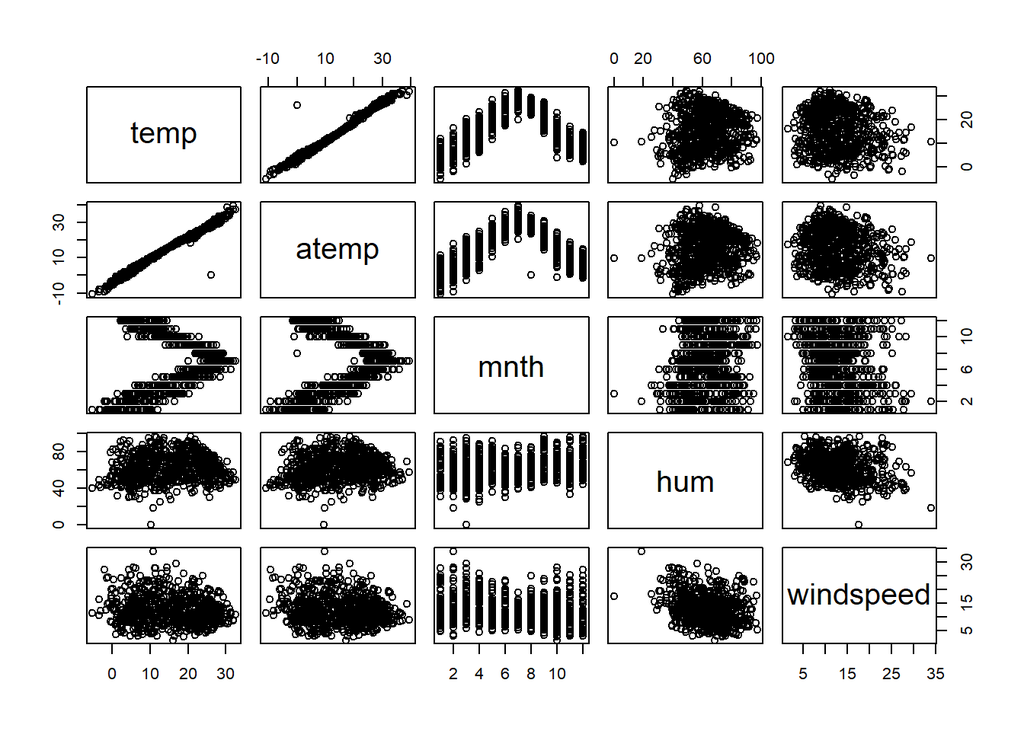

```r
c1 <- c("temp","atemp","mnth","hum","windspeed")
pairs(bikes[,c1])
```

**Hint**: A complete example of how to use the `pairs()` command to construct such plots may be found here: [Pairs plot example](http://www.andrew.cmu.edu/user/achoulde/94842/lectures/lecture08/lecture08-94842.html#collinearity-and-pairs-plots)

##### **(b)** Are any of the predictors highly correlated? Are you surprised that these predictors are highly correlated, or can you think of a reason for why it makes sense that they should be correlated?

- **Yes, the temp, and atemp predictors are the most correlated, I’m not totally surprised, due to the fact that temp and atemp are both related to temperature (with one being the temperature in Celsius, and the other being the fell-temperature in Celsius), just with one being more accurate then the other, though i think mnth would be a alright second-runner up, for good correlation.**

##### **(c)** Refit your regression model, but this time **omit** the `temp` variable. Display the coefficients table for this model.

```r
x3 <- bikes[c("cnt","atemp","mnth","hum","windspeed")]

bikes3.lm <- lm(cnt~ atemp+ mnth, hum+ windspeed,data = bikes)

#bikes3.lm  <- lm(cnt ~ atemp + mnth + hum + windspeed,bikes)

summary(bikes3.lm)
```

```
##
## Call:
## lm(formula = cnt ~ atemp + mnth, data = bikes, subset = hum +
##     windspeed)
##
## Residuals:
##      Min       1Q   Median       3Q      Max
## -1889.07   -38.93    72.21   347.08  1410.70
##
## Coefficients:
##             Estimate Std. Error t value Pr(>|t|)
## (Intercept)  903.261    123.016   7.343 5.62e-13 ***
## atemp         50.269      4.097  12.271  < 2e-16 ***
## mnth         293.359     42.081   6.971 7.05e-12 ***
## ---
## Signif. codes:  0 '***' 0.001 '**' 0.01 '*' 0.05 '.' 0.1 ' ' 1
##
## Residual standard error: 556.1 on 728 degrees of freedom
## Multiple R-squared:  0.2818, Adjusted R-squared:  0.2799
## F-statistic: 142.8 on 2 and 728 DF,  p-value: < 2.2e-16
```

```r
tidy(bikes3.lm) #%>% kable
```

```
## # A tibble: 3 × 5
##   term        estimate std.error statistic  p.value
##   <chr>          <dbl>     <dbl>     <dbl>    <dbl>
## 1 (Intercept)    903.     123.        7.34 5.62e-13
## 2 atemp           50.3      4.10     12.3  1.35e-31
## 3 mnth           293.      42.1       6.97 7.05e-12
```

```r
glance(bikes3.lm ) %>% kable(caption = "table4", digits = 3)
```

table4

| r.squared | adj.r.squared | sigma | statistic | p.value | df | logLik | AIC | BIC | deviance | df.residual | nobs |
| --- | --- | --- | --- | --- | --- | --- | --- | --- | --- | --- | --- |
| 0.282 | 0.28 | 556.103 | 142.847 | 0 | 2 | -5656.358 | 11320.72 | 11339.09 | 225134473 | 728 | 731 |

```r
head(augment(bikes3.lm )) %>% datatable
```

|  | .rownames | cnt | atemp | mnth | .fitted | .resid | .hat | .sigma | .cooksd | .std.resid |
| --- | --- | --- | --- | --- | --- | --- | --- | --- | --- | --- |
| 1 | 91 | 2227 | 2.707964 | 4 | 2212.822668163875 | 14.17733183612518 | 0.00883628766367179 | 556.4851746579941 | 1.9486605486205e-06 | 0.02560745968533608 |
| 2 | 86 | 1693 | 0.5223739999999992 | 3 | 1809.596274097847 | -116.5962740978471 | 0.003166874982841343 | 556.4685700312513 | 4.670070822448521e-05 | -0.2099994376426179 |
| 3 | 60 | 1851 | 1.416013999999997 | 3 | 1854.518838428566 | -3.518838428566369 | 0.002652282458063548 | 556.4854099398091 | 3.558716189514508e-08 | -0.00633608094713442 |
| 4 | 69 | 623 | 9.454088000000002 | 3 | 2258.586355952494 | -1635.586355952494 | 0.001919506762293493 | 553.1629512352749 | 0.005556145294125407 | -2.943983591016176 |
| 5 | 56 | 1461 | 7.130426 | 2 | 1848.419193453685 | -387.4191934536848 | 0.007700522728584952 | 556.2984542769854 | 0.001265217156052631 | -0.699365881111275 |
| 6 | 57 | 1969 | 2.624672 | 2 | 1621.918562412778 | 347.0814375872221 | 0.006741119934946172 | 556.3355118264024 | 0.0008872337242329824 | 0.6262458331531675 |

```r
kable(summary(bikes3.lm)$coef, digits = c(3, 3, 3, 4))
```

|  | Estimate | Std. Error | t value | Pr(>\|t\|) |
| --- | --- | --- | --- | --- |
| (Intercept) | 903.261 | 123.016 | 7.343 | 0 |
| atemp | 50.269 | 4.097 | 12.271 | 0 |
| mnth | 293.359 | 42.081 | 6.971 | 0 |

```r
bikes3.lm$coefficients
```

```
## (Intercept)       atemp        mnth
##    903.2613     50.2692    293.3585
```

```r
view(x3)
```

##### **(d)** What is the coefficient of `atemp` in this new model? Is it very different from the `atemp` coefficient estimated in part **(b)**? Is it statistically significant? Explain your findings.

# Optional Material Below

### Problem 4: Exploring non-linearities

> **Hint**: For this problem, you will find it useful to know about the `jitter` feature in graphics. [Begin by reviewing the code at this link](http://www.andrew.cmu.edu/user/achoulde/94842/misc/extra_tips.html#jittering-points), and be sure to use what you feel to be an appropriate amount of jitter in your plots for **(a)**, **(b)** and **(c)**. You **should not** use jitter for parts **(d)** onward.

##### **(a)** Using `ggplot2` graphics, construct a scatterplot of `cnt` (bikeshare count) across `mnth` (month of the year). Describe what you see. Does a linear relationship appear to be a good way of modeling how bikeshare count varies with month?

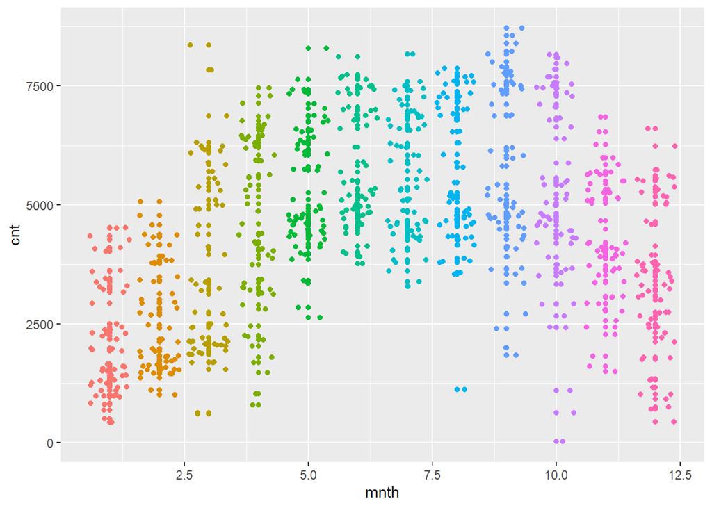

```r
qplot(data = bikes, x = mnth, y = cnt, color = as.factor(mnth)) + geom_jitter() + guides(color = FALSE)
```

##### **(b)** Use `ggplot2`’s `stat_smooth()` overlays to try out *different degree polynomial fits* for modeling the relationship between `cnt` and `month`. Display the lowest degree polynomial fit that appears to nicely capture the trends in the data. Explain your choice.

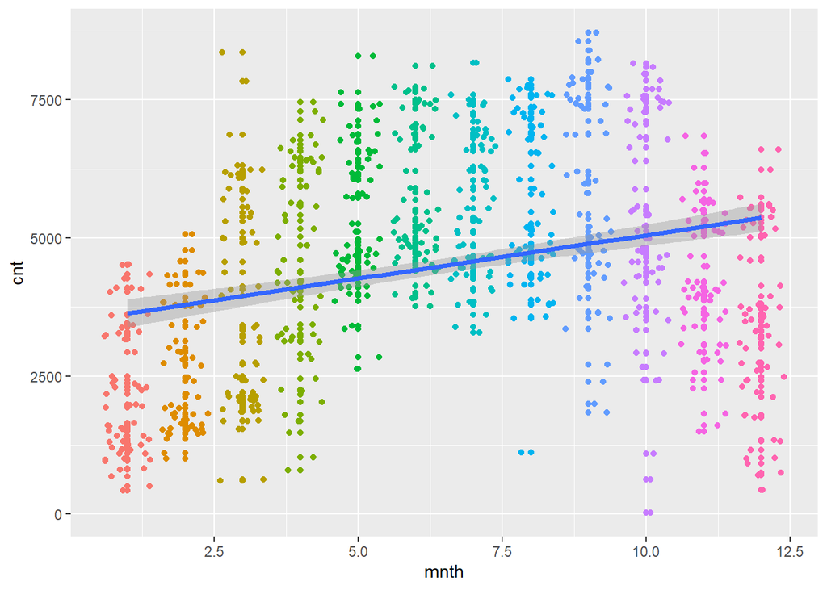

```r
qplot(data = bikes, x = mnth, y = cnt, color = as.factor(mnth)) + geom_jitter() + guides(color = FALSE) + stat_smooth(aes(group = 1), method = "lm", formula = y ~ poly(x, 1), lwd = 1.25)
```

##### **(c)** Use `ggplot2`’s `stat_smooth()` overlays to try out *different step functions* for modeling the relationship between `cnt` and `month`. Display the model with the smallest number of “breaks” or “cuts” that nicely captures the trends in the data. Explain your choice.

You may want to look at

https://www.andrew.cmu.edu/user/achoulde/95791/lectures/code/week1.html

to get some options.

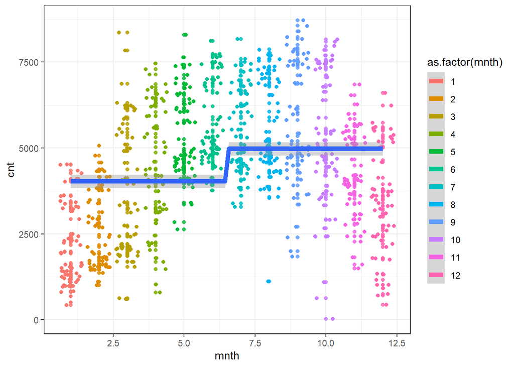

```r
qplot(data = bikes, x = mnth, y = cnt,
      xlab = "mnth", ylab = "cnt", colour = as.factor(mnth), alpha = I(0.85)) + geom_jitter() +
  stat_smooth(aes(group = 1), method = "lm", formula = y ~ cut(x, breaks = c(2)), lwd = 2.25) +
  theme_bw()
```

- **I went for breaks to be around 2, because any real number before that, would cause the mdoel to not compute**

##### Which do you think better describes the relationship between `cnt` and `mnth`: Polynomials, or Step Functions? Explain your answer.

- **I personally believe that they polynomial models are better to read, and understand the correlation between the number of riders, and the months they tend to ride more in.**

##### **(d)** Repeat parts **(a)** and **(b)** to determine appropriate degree polynomials for modeling the relationship between `cnt` and the other inputs: `atemp`, `hum` and `windspeed`. Summarize your choices. (Note: your polynomials can have different degrees for different inputs.)

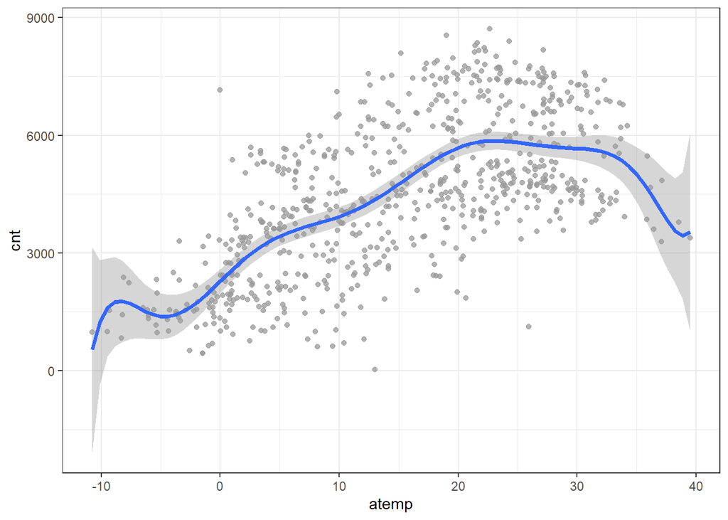

```r
qplot(data = bikes, x = atemp, y = cnt,
      xlab = "atemp", ylab = "cnt", colour = I(cbPalette[1]), alpha = I(0.75)) +
  stat_smooth(method = "lm", formula = y ~ poly(x, 10), lwd = 1.25) +
  theme_bw()
```

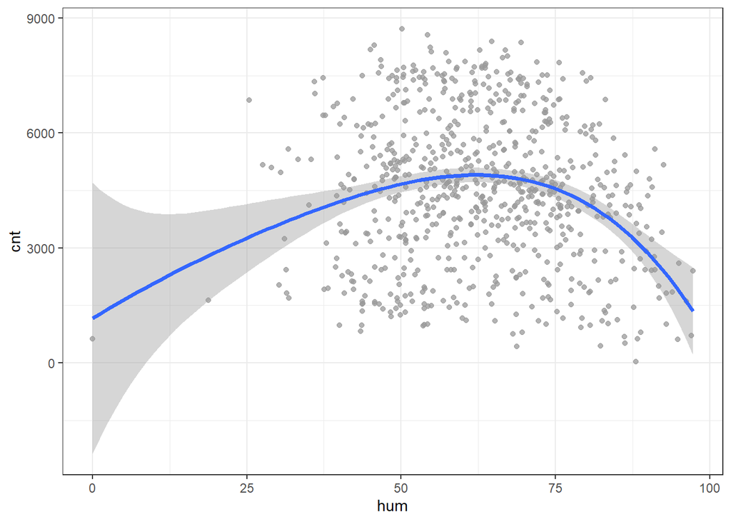

```r
qplot(data = bikes, x = hum, y = cnt,
      xlab = "hum", ylab = "cnt", colour = I(cbPalette[1]), alpha = I(0.75)) +
  stat_smooth(method = "lm", formula = y ~ poly(x, 4), lwd = 1.25) +
  theme_bw()
```

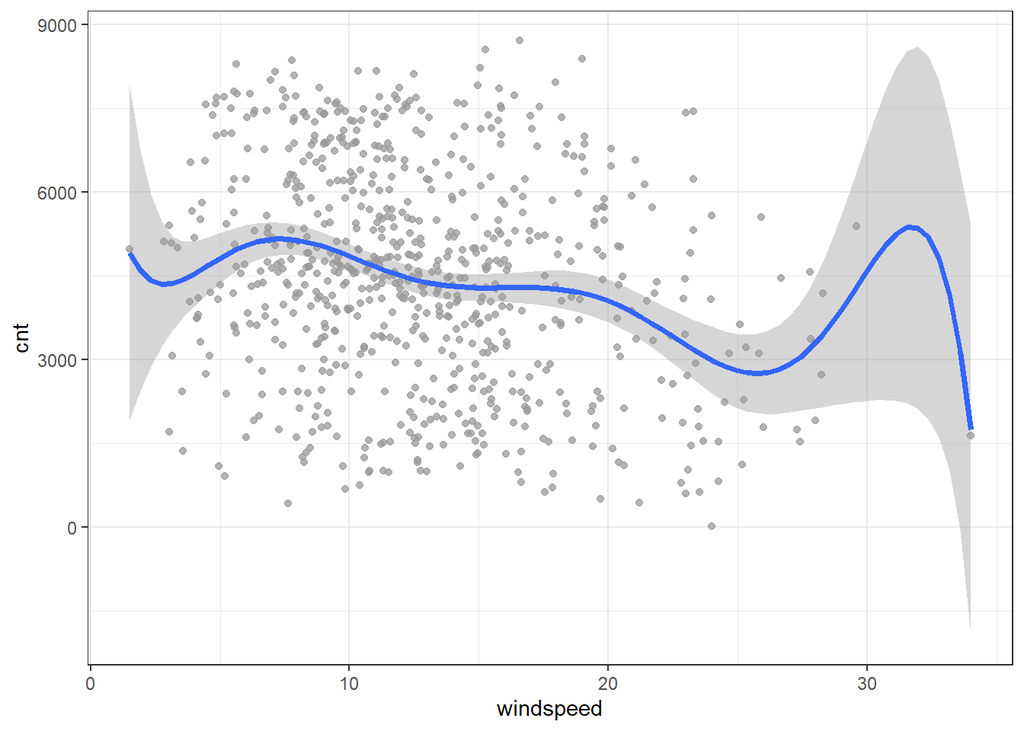

```r
qplot(data = bikes, x = windspeed, y = cnt,
      xlab = "windspeed", ylab = "cnt", colour = I(cbPalette[1]), alpha = I(0.75)) +
  stat_smooth(method = "lm", formula = y ~ poly(x, 7), lwd = 1.25) +
  theme_bw()
```

-**I believe that riders tend to ride their bikes when the weather,humidity and windspeed are moderate, but not in extremities, as the diagrams represent**

##### **(e)** Use your answers to parts **(b)** and **(d)** to fit a polynomial regression model that regresses `cnt` on polynomials in the input variables: `atemp`, `mnth`, `hum`, and `windspeed`. How does the R-squared of this model compare to the R-squared of the model you fit in Problem 3(d)?

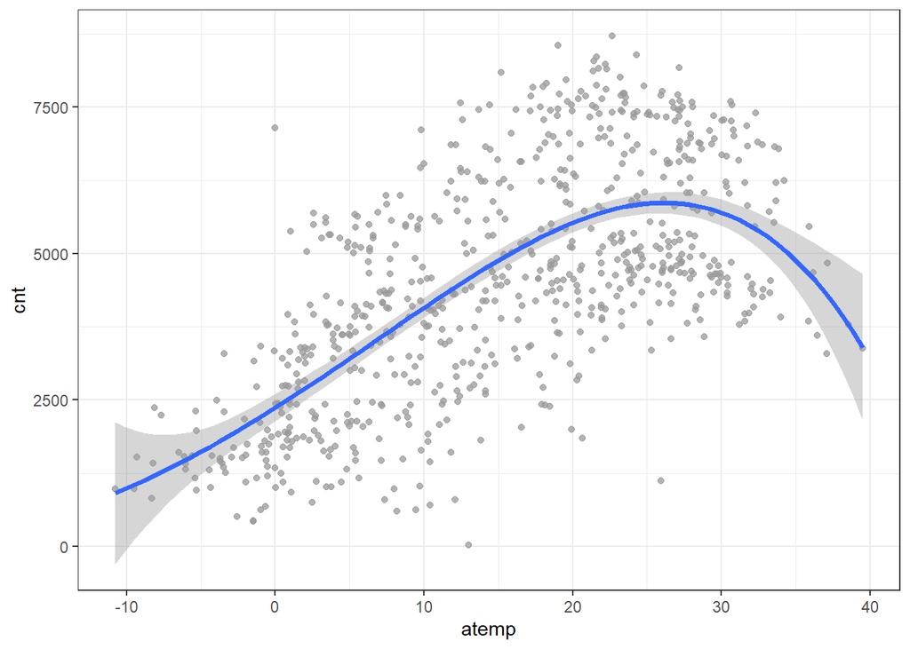

```r
qplot(data = bikes, x = atemp, y = cnt,
      xlab = "atemp", ylab = "cnt", colour = I(cbPalette[1]), alpha = I(0.75)) +
  stat_smooth(method = "lm", formula = y ~ poly(x, 4), lwd = 1.25) +
  theme_bw()
```

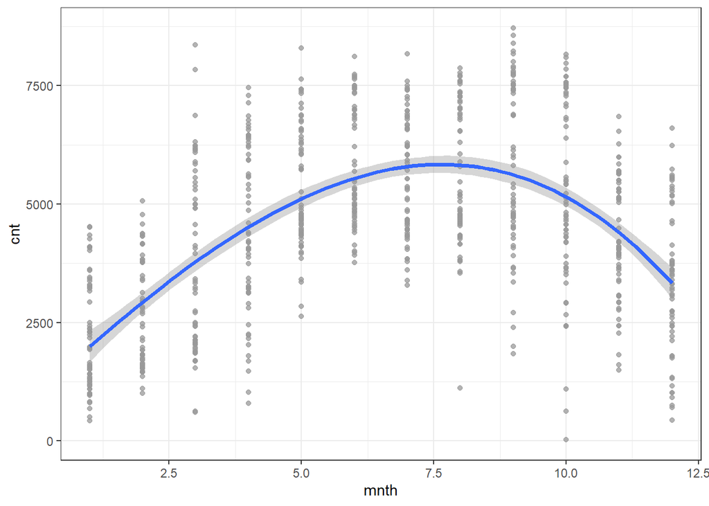

```r
qplot(data = bikes, x = mnth, y = cnt,
      xlab = "mnth", ylab = "cnt", colour = I(cbPalette[1]), alpha = I(0.75)) +
  stat_smooth(method = "lm", formula = y ~ poly(x, 3), lwd = 1.25) +
  theme_bw()
```

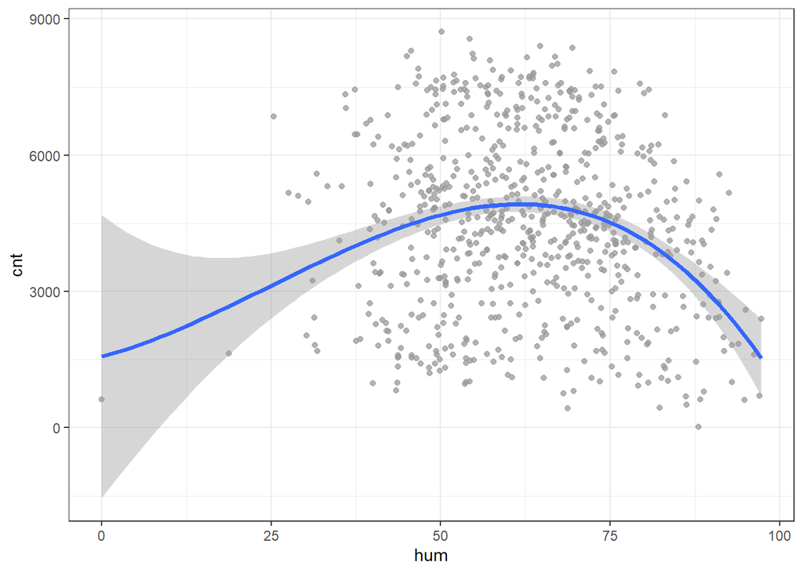

```r
qplot(data = bikes, x = hum, y = cnt,
      xlab = "hum", ylab = "cnt", colour = I(cbPalette[1]), alpha = I(0.75)) +
  stat_smooth(method = "lm", formula = y ~ poly(x, 3), lwd = 1.25) +
  theme_bw()
```

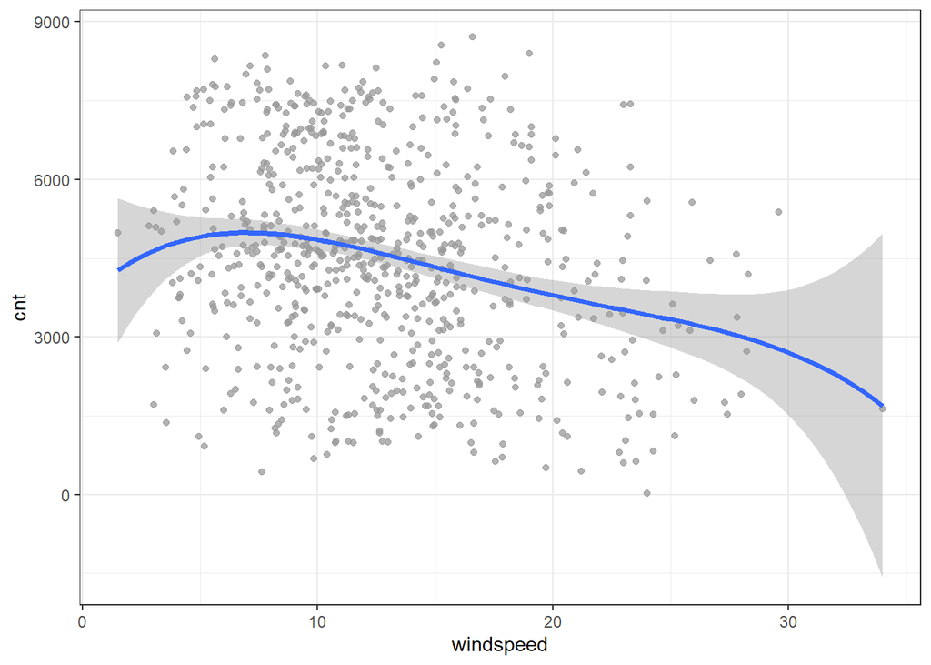

```r
qplot(data = bikes, x = windspeed, y = cnt,
      xlab = "windspeed", ylab = "cnt", colour = I(cbPalette[1]), alpha = I(0.75)) +
  stat_smooth(method = "lm", formula = y ~ poly(x, 4), lwd = 1.25) +
  theme_bw()
```

##### **(f)** What is the total number of parameters in the model you fit in part **(e)**? How does this compare to the number of parameters in the model fit in Problem 3(d)?

- **I believe the total number of parameters in part e, are more then that within part d.**